# 3. Calculating utilization distribution areas

Yuri Niella & Hugo Flávio

2020-06-11

## Index

1. Preparing the data
2. Refining the shortest paths in-water
3. Calculating utilization distribution areas

## 3. Calculating utilization distribution areas

After estimating the in-water shortest paths, we can now use the output from `runRSP()` to calculate utilization distribution areas using **dynamic Brownian Bridge Movement Models** with the `dynBBMM()` function. If you are using a geographic coordinate reference system, here you will need to know the [UTM zone](http://www.dmap.co.uk/utmworld.htm) of your study site and specify it using the argument `UTM`. By default, the analysis will run for all transmitters detected, but you can determine also which transmitters you would like to include using `tags`.

### 3.1. Total dynamic Brownian Bridge Movement Model (group dBBMM)

This option calculates a series of dBBMM for each animal track from all the groups monitored and included in the `runRSP()` analysis. Track **quality checks** are performed to ensure that only good tracks which allow the dBBMM to converge are included in the analysis. This is an example of the returned messages from `dynBBMM()`:

```
dbbmm.results <- dynBBMM(input = rsp.results, UTM = 32)

M: Preparing data to apply dBBMM.
M: No specific transmitters selected. All the data will be used for analysis.
Warning: 7 track(s) in group R64K-4075 have less than eight detections and will not be used.
Warning: 1 track(s) in group R64K-4075 are shorter than 30 minutes and will not be used.
Warning: 2 individual detections were removed in group R64K-4125 due to simultaneous detections at two receivers.
Warning: 2 track(s) in group R64K-4125 have less than eight detections and will not be used.
Warning: 1 track(s) in group R64K-4128 have less than eight detections and will not be used.
Warning: 2 track(s) in group R64K-4128 are shorter than 30 minutes and will not be used.
Warning: 6 track(s) in group R64K-4138 have less than eight detections and will not be used.
M: In total, 93 detections were excluded as they failed the track quality checks.
```

You can suppress the individual warning messages by setting `verbose` to FALSE. You will still receive the final message indicating how many detections were excluded.

After calculating UDs, the **land areas** are excluded so that the final results represent only **in-water areas of use**. The overall overlap between each group monitored is also calculated.

```
M: Subtracting land areas from output.
M: Calculating overlaps between groups.
M: Storing final results.
```

The metadata on the dBBMMs are saved in the `$valid.tracks` object as data frame:

| Group | Tag | Track | valid.n | First.time | Last.time | Timespan |
| --- | --- | --- | --- | --- | --- | --- |
| A | R64K-4075 | Track_03 | 125 | 2018-03-07 00:41:10 | 2018-03-07 08:20:02 | 7.64 hours |
| A | R64K-4075 | Track_08 | 27 | 2018-04-23 05:10:47 | 2018-04-23 08:43:45 | 3.54 hours |
| A | R64K-4075 | Track_09 | 303 | 2018-04-24 11:40:56 | 2018-04-26 01:00:13 | 37.32 hours |
| B | R64K-4125 | Track_02 | 206 | 2018-04-21 13:13:24 | 2018-04-23 09:09:34 | 43.93 hours |
| B | R64K-4125 | Track_03 | 1118 | 2018-04-25 11:44:05 | 2018-04-28 14:10:14 | 74.43 hours |

Included is information on the biological group (Group) tracked, number of valid locations (valid.n) used, and the duration of each model (Timespan) in hours.

You can use `plotContours()` to visualize any of the dBBMM calculated by specifying the `group` and `track` you want to plot:

```
plotContours(input = dbbmm_all, tag = "R64K-4138", track = "10")
plotContours(input = dbbmm_all, tag = "R64K-4125", track = "3")
```

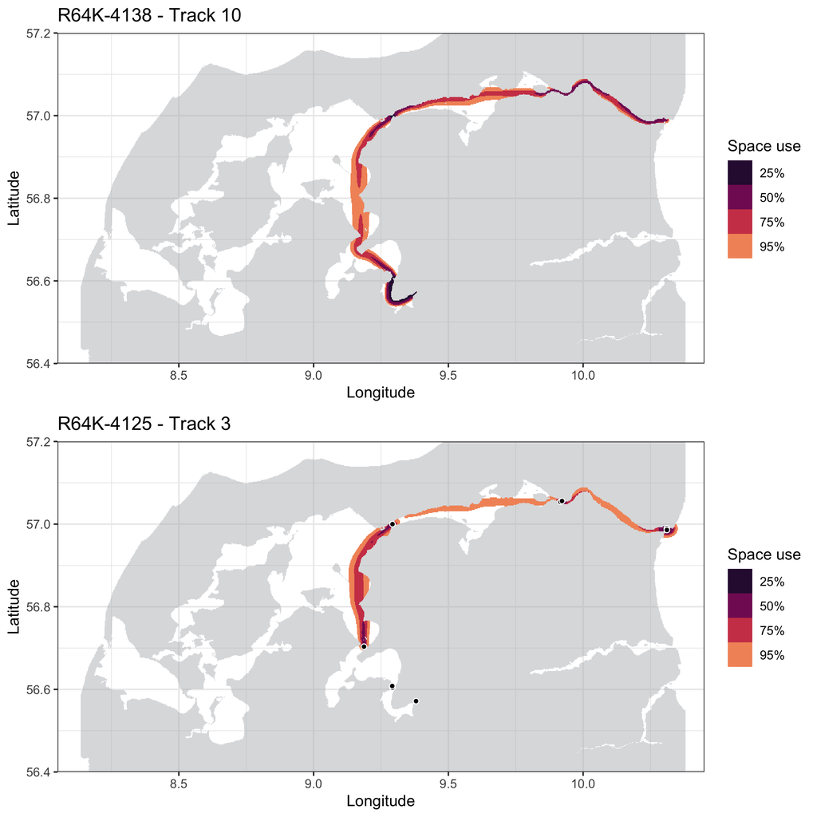

The `breaks` argument can be used to specify which contours to plot. By default, the **25%**, **50%**, **75%**, and **95%** contours are returned. Again `addStations()` can be used to add the receiver locations.

### 3.2. Fine-scale dynamic Brownian Bridge Movement Model (timeslot dBBMM)

dBBMMs can also be calculated according to a moving temporal window. This allows investigating how the space-use overlap between the different groups varied during the study period. It is useful for assessing the influence of environmental parameters upon space-use of different groups tracked within the study area. The same `dynBBMM()` function is used, but here the argument `timeframe` has to be defined in hours as the temporal window. The total tracking period will be divided into `timeslots`, and dBBMMs calculated for each group monitored (for each timeslot). Overlapping areas are now calculated for each `timeslot` and the corresponding metadata stored in the `$timeslots` object:

```
time.dbbmm.results <- dynBBMM(input = rsp.results, UTM.zone = 56, breaks = c(0.5, 0.95), timeframe = 24) # 24-h timeslots
time.dbbmm.results$timeslots[400:410, ]
```

| slot | start | stop | Bream | Luderick | Tarwhine |
| --- | --- | --- | --- | --- | --- |
| 400 | 2014-10-06 00:00:00 | 2014-10-07 00:00:00 | FALSE | FALSE | FALSE |
| 401 | 2014-10-07 00:00:00 | 2014-10-08 00:00:00 | FALSE | FALSE | FALSE |
| 402 | 2014-10-08 00:00:00 | 2014-10-09 00:00:00 | FALSE | FALSE | FALSE |
| 403 | 2014-10-09 00:00:00 | 2014-10-10 00:00:00 | FALSE | FALSE | FALSE |
| 404 | 2014-10-10 00:00:00 | 2014-10-11 00:00:00 | TRUE | FALSE | TRUE |
| 405 | 2014-10-11 00:00:00 | 2014-10-12 00:00:00 | FALSE | FALSE | TRUE |
| 406 | 2014-10-12 00:00:00 | 2014-10-13 00:00:00 | FALSE | FALSE | TRUE |
| 407 | 2014-10-13 00:00:00 | 2014-10-14 00:00:00 | FALSE | FALSE | TRUE |
| 408 | 2014-10-14 00:00:00 | 2014-10-15 00:00:00 | FALSE | FALSE | TRUE |
| 409 | 2014-10-15 00:00:00 | 2014-10-16 00:00:00 | FALSE | FALSE | TRUE |
| 410 | 2014-10-16 00:00:00 | 2014-10-17 00:00:00 | FALSE | FALSE | TRUE |

In the example above (daily timeslots set using `timeframe = 24`) we can notice that in timeslots 400 to 403 none of the three groups monitored were detected, whereas both **Bream** and **Tarwhine** groups got detected in **slot 404** and from **slot 405** to **slot 410** only **Tarwhine** were detected.

The `$track.areas` object for each tracked group will now have a first column named **Slot**, which identifies the `timeslot` for each of the dBBMM calculated:

```
time.dbbmm.results$track.areas$Bream[24:30, ]
```

| Slot | Track | Start | Stop | Area.5 | Area.95 | Time.lapse.min |
| --- | --- | --- | --- | --- | --- | --- |
| 404 | A69-9004-485_Track_01 | 2014-10-10 10:08:08 | 2014-10-10 10:38:15 | 289 | 1245 | 30.11667 |
| 411 | A69-9004-485_Track_02 | 2014-10-17 12:41:35 | 2014-10-17 23:59:03 | 635 | 3489 | 677.46667 |
| 412 | A69-9004-485_Track_02 | 2014-10-18 00:09:01 | 2014-10-18 23:26:49 | 670 | 4518 | 1397.80000 |
| 413 | A69-9004-485_Track_02 | 2014-10-19 00:18:55 | 2014-10-19 06:45:37 | 231 | 1062 | 386.70000 |
| 425 | A69-9004-485_Track_04 | 2014-10-31 10:24:47 | 2014-10-31 23:51:01 | 685 | 2731 | 806.23333 |
| 426 | A69-9004-485_Track_04 | 2014-11-01 00:00:59 | 2014-11-01 23:58:59 | 1158 | 5344 | 1438.00000 |
| 427 | A69-9004-485_Track_04 | 2014-11-02 00:08:18 | 2014-11-02 23:53:08 | 624 | 2515 | 1424.83333 |

Here we can see that the Bream **A69-9004-485** was detected consecutively between `2014-10-17 12:41:35` and `2014-10-19 06:45:37` (Track_02) and again between `2014-10-31 10:24:47` and `2014-11-02 23:53:08` (Track_04).

The following command line can help you assess if any other group got detected during a particular `timeslot`:

```
> time.dbbmm.results$timeslots[404, ]
    slot               start                stop Bream Luderick Tarwhine
404  404 2014-10-10 00:00:00 2014-10-11 00:00:00  TRUE    FALSE     TRUE
```

Yes, both **Bream** and **Tarwhine** were detected between `2014-10-10 00:00:00` and `2014-10-11 00:00:00` (**timeslot 404**). We can now inspect whether the two groups overlapped or not:

```
> time.dbbmm.results$overlap.areas$`0.95`$percentage$`404`
             Bream Luderick  Tarwhine
Bream           NA       NA 0.9799197
Luderick        NA       NA        NA
Tarwhine 0.9799197       NA        NA
```

This shows that the two groups had an overlap of 97.99% at the 95% dBBMM contour during this particular `timeslot` (or in this case, day). We can now see exactly where the overlap occurred by plotting the space use models and the overlap contours using:

```
plotContours(input = time.dbbmm.results, group = "Bream", track = "A69-9004-485_Track_01", main = "A69-9004-485 (Bream)", stations = TRUE, timeslot = 404)
plotContours(input = time.dbbmm.results, group = "Tarwhine", track = "A69-9004-489_Track_1", main = "A69-9004-489 (Tarwhine)", stations = TRUE, timeslot = 404)
```

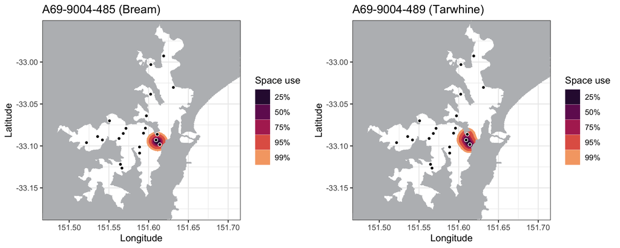

Setting the argument `stations = TRUE` will include the locations of acoustic receivers in the plot.

Here we can see how these two transmitters really occurred in a similar region during `timeslot = 404`. To inspect for the total space use areas at group level, and the exact overlap in space and time we can use `plotOverlap()`:

```
> plotOverlap(input = dbbmm_time_24, level = .95, store = TRUE, stations = FALSE, timeslot = 404, main = "2014-10-10")
M: No overlap found between 'Bream' and 'Luderick'.
M: No overlap found between 'Luderick' and 'Tarwhine'.
```

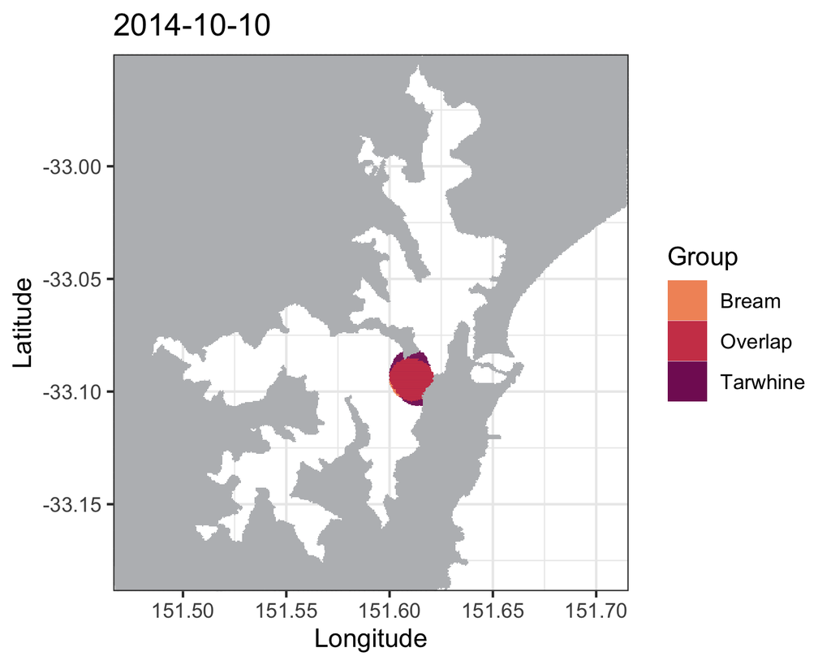